# ASS1

Clayton Glenn

February 8, 2018

# 1 Working Directory

```r
getwd()
```

```
## [1] "C:/Users/cglen/Documents/Stat Methods/Assignments/ASS1"
```

# 2 Question 1

There are 4 assignments that equal 15% of my grade and all work must be shown to receive full credit. There are 16 Labs in the class that equal 10% of my grade. I cannot deposit my lab into the drop box after time is up. The 1 project I have is 10% of my total grade. The project is over Simple Linear Regression and needs to be submitted in the outlined format provided on canvas. Clickers are done in class and worth 10% of my total grade. Missing a couple class will most likely not change my grade. Chapter quizzes are online and equal 5% of my total grade. They are usually 10 questions and are graded automatically. I have 2 midterm exams worth a total of 20% of my grade. The midterms should not overlap in content, but the final exam will. My final in this class is worth 30% of my grade and is cumulative. The breakup of the final exam will be about 1/3 Exams 1 and 2, and 2/3 from chapters 8 and 10. The grading scale in this class is as follows: A(90-100), B(80-89), C(60-79), D(50-59), F(0-49) without the possibility of a curve of the total grade, so what you earn is what you get.

# 3 Question 2

## 3.1 Data Read

```r
ddt = read.csv("DDT.csv")
```

## 3.2 Part A

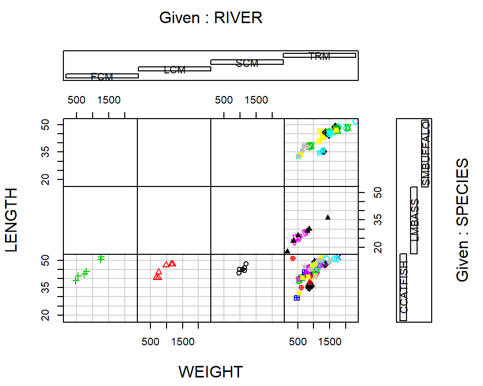

```r
m=with(ddt, as.numeric(levels(factor(MILE)))) # A
colm=c()
for(i in 1:length(ddt$MILE)){
colm[i]=which(ddt$MILE[i]==m) #B
}
coplot(LENGTH ~ WEIGHT | RIVER*SPECIES, ddt, col = colm, pch = colm)
```

## 3.3 Part B

This coplot shows the broken-up data of each river and species. The lower far left plot shows the number and size of catfish in the FCM River. The Lower Left Mid plot shows the number and size of catfish in the LCM River, and the Lower Third from the Left plot shows the number and size of catfish that are in the SCM River.

## 3.4 Part C

```r
with(ddt, as.numeric(levels(factor(MILE))))
```

```
##  [1]   1   3   5 275 280 285 290 295 300 305 310 315 320 325 330 340 345
```

Line A shows the Each independent mile number in an array of numbers.

## 3.5 Part D

```r
which(ddt$MILE[i]==m)
```

```
## [1] 17
```

Line B shows the Length of the array of independent mile numbers.

## 3.6 Part E

The top six plots are empty due to the fact that FCM, LCM, and SCM Rivers do not contain SMBUFFALO or LMBASS, so no data is shown for the coplots.

## 3.7 Part F

$$Mean=\frac{\sum_{i=1}^nX_{i}}{N}$$

```r
with(ddt[ddt$RIVER=="FCM" & ddt$SPECIES=="CCATFISH",],{
  mean(DDT)
})
```

```
## [1] 45
```

The mean value of DDT in CCATFISH Caught in the FCM river is 45.

# 4 Question 3

## 4.1 Part A

Length of Maximum Span(Feet) = Quantitative

## 4.2 Part B

Number of Vehicle Lanes = Quantitative

## 4.3 Part C

Toll Bridge = Qualitative

## 4.4 Part D

Average Daily Traffic = Quantitative

## 4.5 Part E

Condition of Deck(good, fair, or poor) = Qualitative

## 4.6 Part F

Bypass or Detour Length(Miles) = Quantitative

## 4.7 Part G

Route Type(interstate, U.S., state country, or city) = Qualitative

# 5 Question 4

## 5.1 Simple Random Sampling(Simple)

Randomly chose units out of a population.

## 5.2 Stratified Random Sampling(Complex)

Sampling used when units can be separated into strata or groups by characteristics.

## 5.3 Cluster Sampling(Complex)

Sampling used to break down large samples into clusters and then compare them.

## 5.4 Systematic Sampling(Complex)

Sampling used by selecting every Kth element in a population for a random sample.

# 6 Question 5

## 6.1 Data Read

```r
mtbe = read.csv("MTBE.csv")
mtbeo=na.omit(mtbe)
```

## 6.2 Part A

```r
i=sample(1:223,5,replace=FALSE)
mtbe[i,]
```

```
##       pH SpConduct DissOxy RoadsPct IndPct UrbanPct DevPct WellClass
## 116 8.09     248.5    0.37     3.04   11.8    52.54  56.80    Public
## 68  5.83     454.5    5.98     1.62    0.0     7.83  19.92   Private
## 119 8.05     199.9    0.42     0.00    0.0     0.52   0.52    Public
## 36  7.13     542.6    2.73     0.92    0.0    14.69  19.32   Private
## 30  8.48     299.7    0.10     1.39    0.0    20.77  20.77   Private
##     Aquifier   Depth  SafeYld Distance MTBE.Detect MTBE.Level HouseDen
## 116  Bedrock 106.680 378.5011  1090.68 Below Limit        0.2    85.07
## 68   Bedrock  91.440       NA  3249.34 Below Limit        0.2    32.37
## 119  Bedrock  80.772 246.0257  1049.97 Below Limit        0.2    37.92
## 36   Bedrock  60.960       NA  1980.28 Below Limit        0.2   168.77
## 30   Bedrock 137.160       NA  4326.18 Below Limit        0.2    77.37
##     PopDen
## 116  27.31
## 68   22.37
## 119  13.97
## 36   71.34
## 30   28.13
```

## 6.3 Part B

### 6.3.1 Standard Deviation of depth of Bedrock wells

$$Standard Deviation=\frac{\sum_{i=1}^n(X_{i}-\bar{X})^2}{N-1}$$

```r
sd(mtbeo[mtbeo$Aquifier=="Bedrock",]$Depth)
```

```
## [1] 56.45357
```

# 7 Question 6

## 7.1 Data Read

```r
eq = read.csv("EARTHQUAKE.csv")
```

## 7.2 Random Sample

```r
eqsam=sample(1:2929,30,replace=FALSE)
eq[eqsam,]
```

```
##      YEAR MONTH DAY HOUR MINUTE MAGNITUDE
## 1520 1994     1  24   13     28       1.5
## 118  1994     1  17   17     56       4.6
## 2255 1994     1  29   11     25       2.7
## 1488 1994     1  24    9     24       2.6
## 2596 1994     2   3    3     59       1.9
## 9    1994     1  17   12     40       4.3
## 2711 1994     2   4    3     55       1.6
## 2428 1994     2   1   11      8       2.0
## 1786 1994     1  26    4      3       1.8
## 1458 1994     1  24    5     32       1.3
## 949  1994     1  21   14     38       1.9
## 2195 1994     1  29    1     38       1.7
## 169  1994     1  17   22     11       3.5
## 1673 1994     1  25   12      7       1.5
```

[output cut: 16 more lines]

## 7.3 Part A

### 7.3.1 Section i

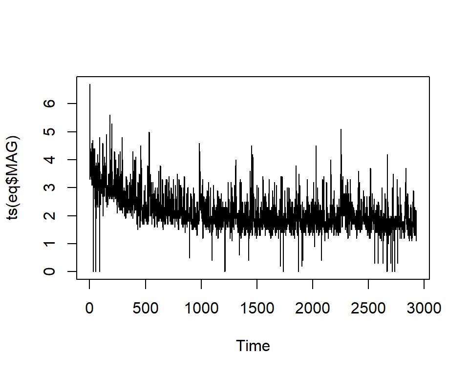

```r
plot(ts(eq$MAG))
```

### 7.3.2 Section ii

$$Median=X_{N/2}$$

```r
median(eq$MAGNITUDE)
```

```
## [1] 2
```

The median of the whole Earthquake data file based on magnitude is 2

# 8 Question 7

## 8.1 Part A

The scientists used a stratified sample.

## 8.2 Part B

The Population was all fish in the Tennessee River and its tributaries.

## 8.3 Part C

The qualitative variables in DDT file is River and Species.

# 9 Question 8

## 9.1 Part A

A bar graph describes the data.

## 9.2 Part B

Number of Robots

## 9.3 Part C

According to the graph, the most used robot design is Legs Only.

## 9.4 Part D

$$Relative Frequency=\frac{Class}{N}$$

```r
15/106
```

```
## [1] 0.1415094
```

```r
8/106
```

```
## [1] 0.0754717
```

```r
63/106
```

```
## [1] 0.5943396
```

```r
20/106
```

```
## [1] 0.1886792
```

## 9.5 Part E - Wrong

```r
freq=c(15,8,63,20)
RL=c("None","Both","LegsO","WheelsO")
x=rep(RL,freq)
```

# 10 Question 9

## 10.1 Part A

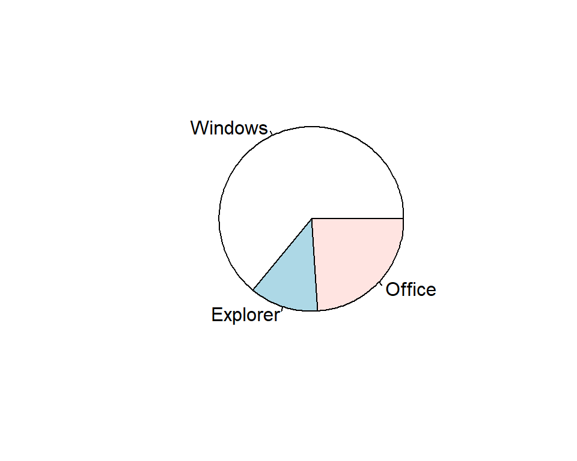

```r
mpfreq=c(32,6,12)
mpt=c("Windows","Explorer","Office")
pie(mpfreq, mpt)
```

Based on the pie chart, Explorer has the lowest proportion of security issues.

## 10.2 Part B - Wrong

```r
pareto<-function(mpfreq,mn="Microsoft Security",...){
  mpfreq.tab<-table(mpfreq)
  xx.tab<-sort(mpfreq.tab, decreasing=TRUE,index.return=FALSE)
  cs<-cumsum(as.vector(xx.tab))
  lenx<-length(mpfreq.tab)
  bp<-barplot(xx.tab,ylim=c(0,max(cs)),las=2)
  lb<-seq(0,cs[lenx],l=11)
  axis(side=4,at=lb,labels=paste(seq(0,100,length=11),"%",
  sep =""),las=1,line=-1,col="Blue",col.axis="Red")
  for(i in 1:(lenx-1)){
    segments(bp[i],cs[i],bp[i+1],cs[i+1],col=i,lwd=2)
  }
  title(main=mn,...)
}
#plot(pareto)
```

# 11 Question 10

```r
swd=read.csv("SWDEFECTS.csv", header=TRUE)
#head(swd)
library(plotrix)
tab=table(swd$defect)
rtab=tab/sum(tab)
round(rtab,2)
```

```
##
## FALSE  TRUE
##   0.9   0.1
```

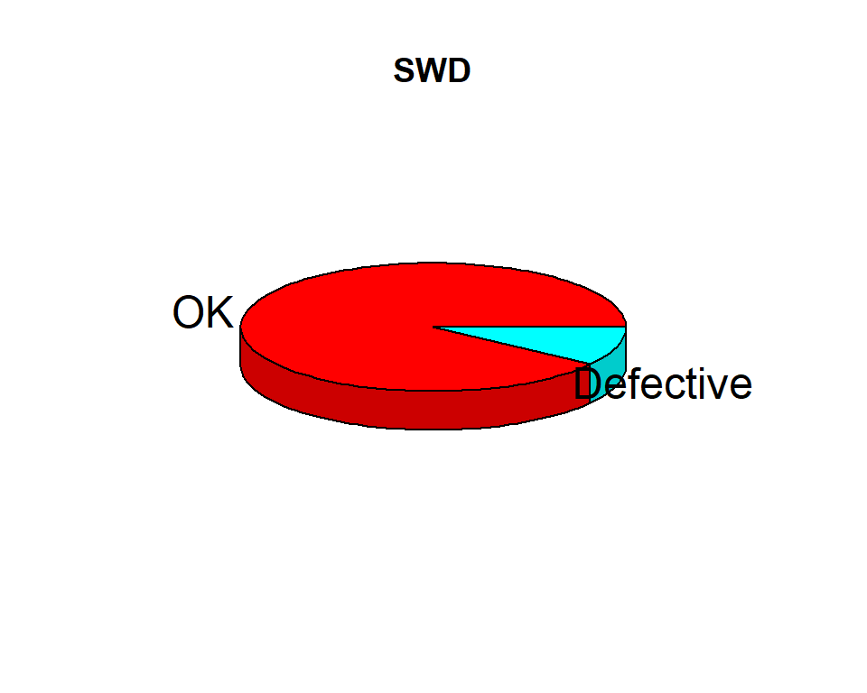

```r
pie3D(rtab,labels=list("OK","Defective"),main="SWD")
```

# 12 Question 11

## 12.1 Data Read

```r
voltage.df<-read.csv("VOLTAGE.csv", header=TRUE)
old<-subset(voltage.df,subset=LOCATION=="OLD")
new<-subset(voltage.df,subset=LOCATION=="NEW")
```

## 12.2 Part A

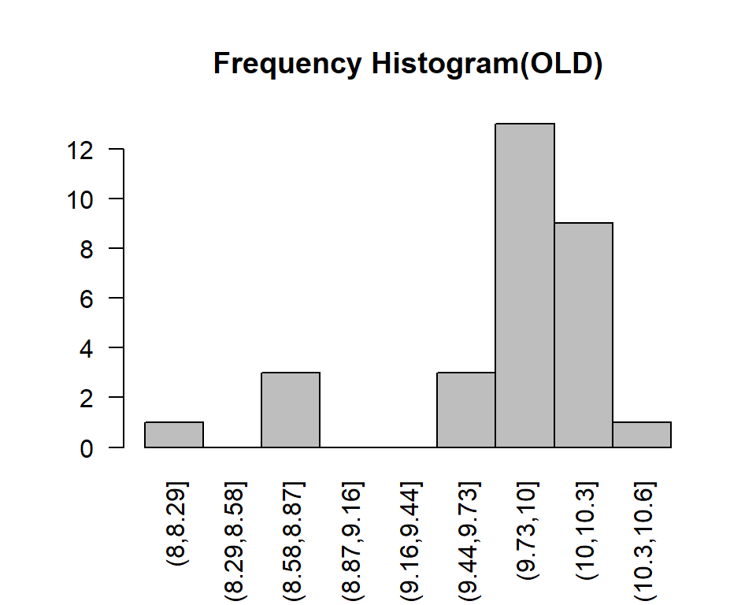

```r
old$VOLTAGE->vtn
lept<-min(vtn)-0.05
rept<-max(vtn)+0.05
rnge<-rept-lept
inc<-rnge/9
seq(lept, rept,by=inc)->cl
cvtn<-cut(vtn,breaks=cl)
new.tab=table(cvtn)
barplot(new.tab,space=0,main="Frequency Histogram(OLD)",las=2)
```

## 12.3 Part B

```r
stem(vtn)
```

```
##
##   The decimal point is at the |
##
##    8 | 1
##    8 | 778
##    9 |
##    9 | 6778888999
##   10 | 000000011122333
##   10 | 6
```

## 12.4 Part C

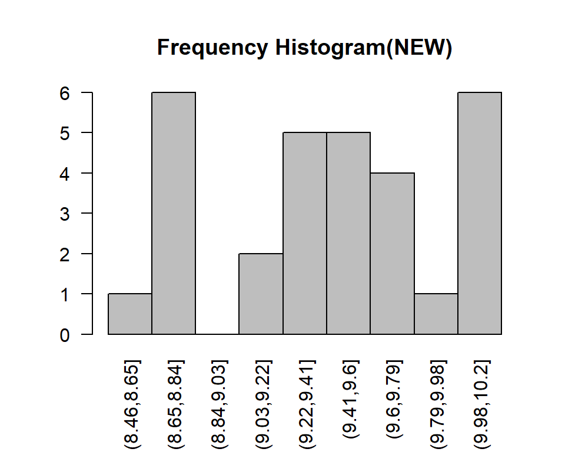

```r
new$VOLTAGE->vtn
lept<-min(vtn)-0.05
rept<-max(vtn)+0.05
rnge<-rept-lept
inc<-rnge/9
seq(lept, rept,by=inc)->cl
cvtn<-cut(vtn,breaks=cl)
new.tab=table(cvtn)
barplot(new.tab,space=0,main="Frequency Histogram(NEW)",las=2)
```

## 12.5 Part D

The New Process is better than the Old process due to less outliers of voltage.

## 12.6 Part E

$$Mean=\frac{\sum_{i=1}^nX_{i}}{N}$$
$$Median=X_{N/2}$$
$$Mode=Class Most Often$$

```r
mean(old$VOLTAGE)
```

```
## [1] 9.803667
```

```r
median(old$VOLTAGE)
```

```
## [1] 9.975
```

```r
which.max(old$VOLTAGE)
```

```
## [1] 7
```

```r
mean(new$VOLTAGE)
```

```
## [1] 9.422333
```

```r
median(new$VOLTAGE)
```

```
## [1] 9.455
```

```r
which.max(new$VOLTAGE)
```

```
## [1] 8
```

We can use the median for the central tendency because the median is close enough to mean and is a better looking number.

## 12.7 Part F

$$\mathcal{Z}Score=\dfrac{10.5-\bar{X}_{i}}S$$

```r
(10.5-mean(old$VOLTAGE))/sd(old$VOLTAGE)
```

```
## [1] 1.287324
```

## 12.8 Part G

```r
(10.5-mean(new$VOLTAGE))/sd(new$VOLTAGE)
```

```
## [1] 2.25041
```

## 12.9 Part H

Based on parts F and G, 10.5 Voltage will more likely occur at the old process. This is due to 10.5 being closer to mean+sd

## 12.10 Part I

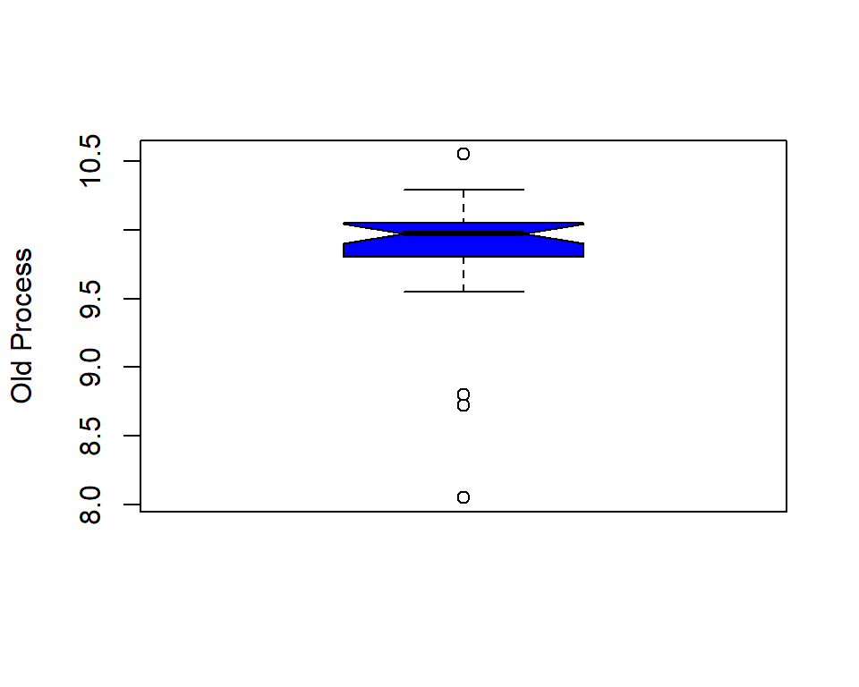

```r
with(old,boxplot(VOLTAGE,ylab="Old Process",col="Blue",notch=TRUE))
```

## 12.11 Part J

```r
old[  (old$VOLTAGE-mean(old$VOLTAGE))/sd(old$VOLTAGE) <= -2 |
      (old$VOLTAGE-mean(old$VOLTAGE))/sd(old$VOLTAGE) >= 2,]
```

```
##    VOLTAGE LOCATION
## 6     8.05      OLD
## 20    8.72      OLD
## 28    8.72      OLD
```

## 12.12 Part K

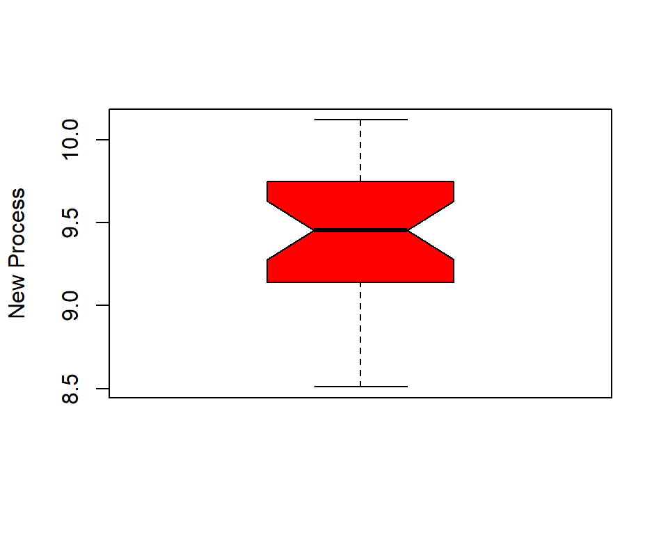

```r
with(new,boxplot(VOLTAGE,ylab="New Process",col="Red",notch=TRUE))
```

## 12.13 Part L

```r
new[  (new$VOLTAGE-mean(new$VOLTAGE))/sd(new$VOLTAGE) <= -2 |
      (new$VOLTAGE-mean(new$VOLTAGE))/sd(new$VOLTAGE) >= 2,]
```

```
## [1] VOLTAGE  LOCATION
## <0 rows> (or 0-length row.names)
```

## 12.14 Part M

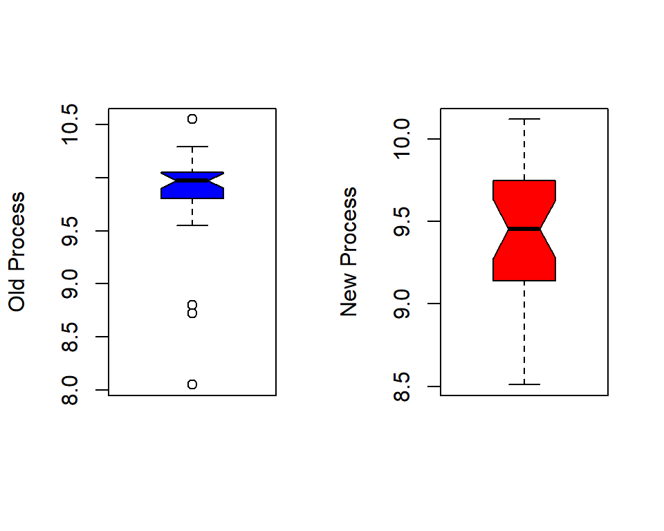

```r
layout(matrix(c(1,2),nr=1,nc=2))
with(old,boxplot(VOLTAGE,ylab="Old Process",col="Blue",notch=TRUE))
with(new,boxplot(VOLTAGE,ylab="New Process",col="Red",notch=TRUE))
```

# 13 Question 12

```r
RP <- c(1.72,2.5,2.16,2.13,1.06,2.24,2.31,2.03,1.09,1.4,2.57,2.64,1.26,2.05,1.19,2.13,1.27,1.51,2.41,1.95)
mean(RP) - sd(RP)*2
```

```
## [1] 0.8331772
```

```r
mean(RP) + sd(RP)*2
```

```
## [1] 2.928823
```

# 14 Question 13

## 14.1 Data Read

```r
gobi.df<-read.csv("GOBIANTS.CSV", header=TRUE)
dry.df = within(gobi.df, {
  reg <- ifelse(Region == "Gobi Desert", "GS","DS")
  reg<-factor(reg)
})
des.df = subset(gobi.df,subset=Region=="Gobi Desert")
```

## 14.2 Part A

$$Mean=\frac{\sum_{i=1}^nX_{i}}{N}$$
$$Median=X_{N/2}$$
$$Mode=Class Most Often$$

```r
mean(gobi.df$AntSpecies)
```

```
## [1] 12.81818
```

The Average Ant Species in all 11 sites.

```r
median(gobi.df$AntSpecies)
```

```
## [1] 5
```

The Amount of Ant Species at the Site that has the exact middle amount of Ant Species.

```r
which.max(gobi.df$AntSpecies)
```

```
## [1] 3
```

## 14.3 Part B

The mean value best suits the data, due to the high volume of species at few sites.

## 14.4 Part C

$$Mean=\frac{\sum_{i=1}^nX_{i}}{N}$$
$$Median=X_{N/2}$$
$$Mode=Class Most Often$$

```r
mean(dry.df[dry.df$reg == "DS",]$PlantCov)
```

```
## [1] 40.4
```

```r
median(dry.df[dry.df$reg == "DS",]$PlantCov)
```

```
## [1] 40
```

```r
which.max(dry.df[dry.df$reg == "DS",]$PlantCov)
```

```
## [1] 2
```

## 14.5 Part D

$$Mean=\frac{\sum_{i=1}^nX_{i}}{N}$$
$$Median=X_{N/2}$$
$$Mode=Class Most Often$$

```r
mean(des.df$PlantCov)
```

```
## [1] 28
```

```r
median(des.df$PlantCov)
```

```
## [1] 26
```

```r
which.max(des.df$PlantCov)
```

```
## [1] 4
```

## 14.6 Part E

# 15 Question 14

## 15.1 Part A

```r
gal.df<-read.csv("GALAXY2.CSV", header=TRUE)
low.df = gal.df[gal.df$VELOCITY < 21000,]
high.df = gal.df[gal.df$VELOCITY > 21000,]
```

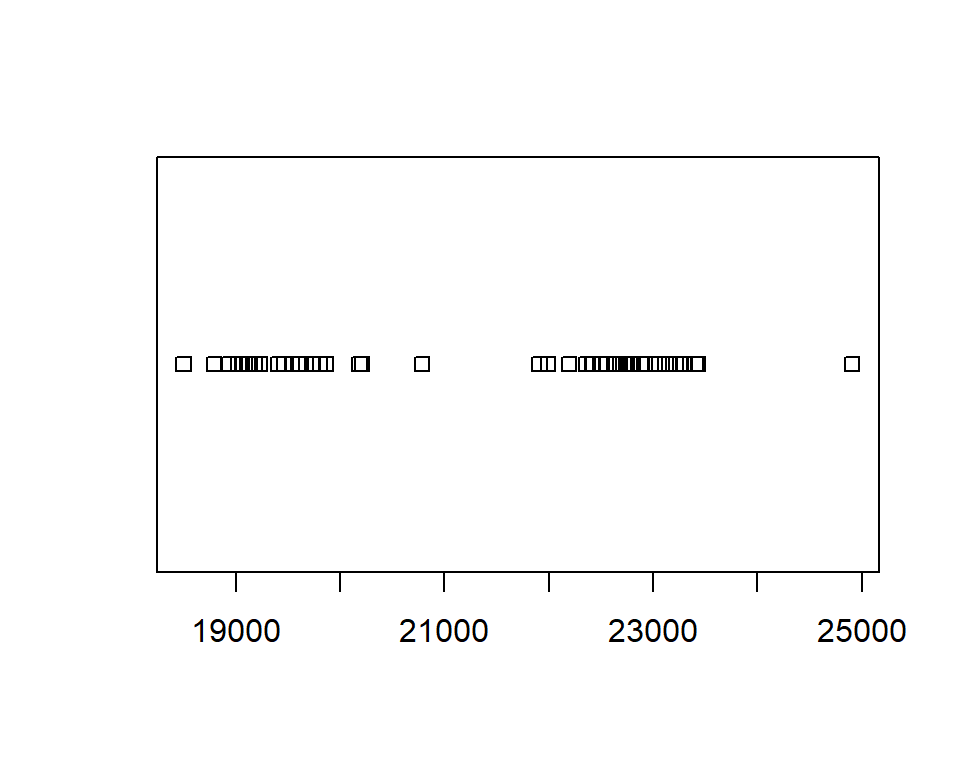

```r
plot(gal.df)
```

## 15.2 Part B

Yes, there are two clusters. One cluster is between 19000 and 20000, and the other cluster is between 22000 and 23000.

## 15.3 Part C

$$Mean=\frac{\sum_{i=1}^nX_{i}}{N}$$
$$Standard Deviation=\frac{\sum_{i=1}^n(X_{i}-\bar{X})^2}{N-1}$$

```r
mean(low.df)
```

```
## [1] 19462.24
```

```r
sd(low.df)
```

```
## [1] 532.2868
```

```r
mean(high.df)
```

```
## [1] 22838.47
```

```r
sd(high.df)
```

```
## [1] 560.9767
```

## 15.4 Part D

The galaxy Velocity of 20000 would fit within A1775A because the velocity is much closer to A1775A’s Mean + SD than A1775B’s Mean - SD.

# 16 Question 15

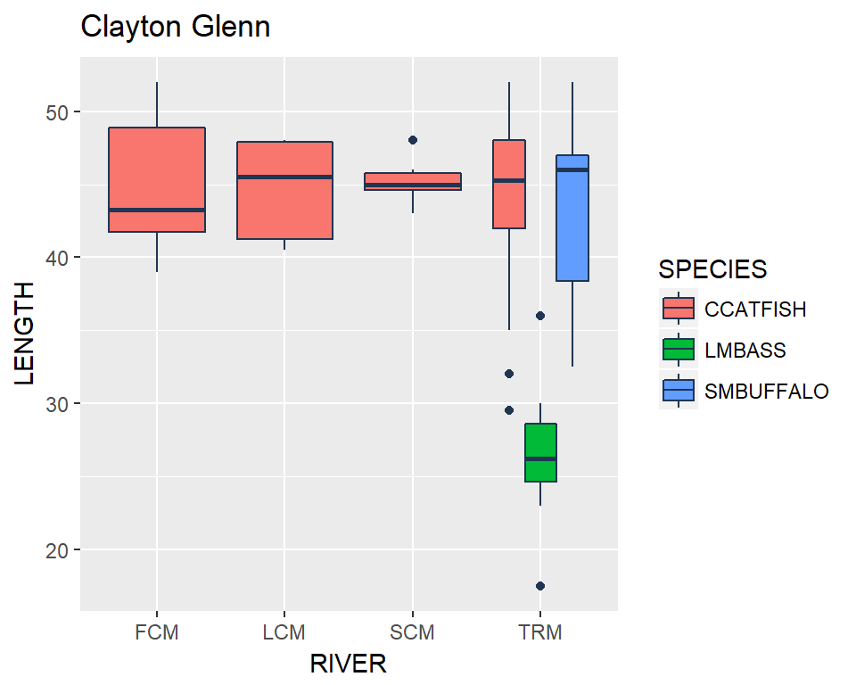

```r
library(ggplot2)
gg <- ggplot(ddt, aes(x=RIVER, y=LENGTH, color=SPECIES, fill = SPECIES))
gg <- gg + geom_boxplot(colour = "#1F3552")
gg <- gg + ggtitle("Clayton Glenn")
show(gg)
```